# Linear Regression Task

### In this regression task we will predict the percentage of marks that a student is expected to score based upon the number of hours they studied. This is a simple linear regression task as it involves just two variables.

## Firstly load the Dataset, but we have a url of dataset so we add (data.table) pakage for url data load….

#### dataload <- fread(“https://raw.githubusercontent.com/AdiPersonalWorks/Random/master/student_scores%20-%20student_scores.csv”)

# Check the Dataset

```r
head(dataload)
```

```
##    Hours Scores
## 1:   2.5     21
## 2:   5.1     47
## 3:   3.2     27
## 4:   8.5     75
## 5:   3.5     30
## 6:   1.5     20
```

```r
summary(dataload)
```

```
##      Hours           Scores
##  Min.   :1.100   Min.   :17.00
##  1st Qu.:2.700   1st Qu.:30.00
##  Median :4.800   Median :47.00
##  Mean   :5.012   Mean   :51.48
##  3rd Qu.:7.400   3rd Qu.:75.00
##  Max.   :9.200   Max.   :95.00
```

# 1. Plot (Scatter Plot)

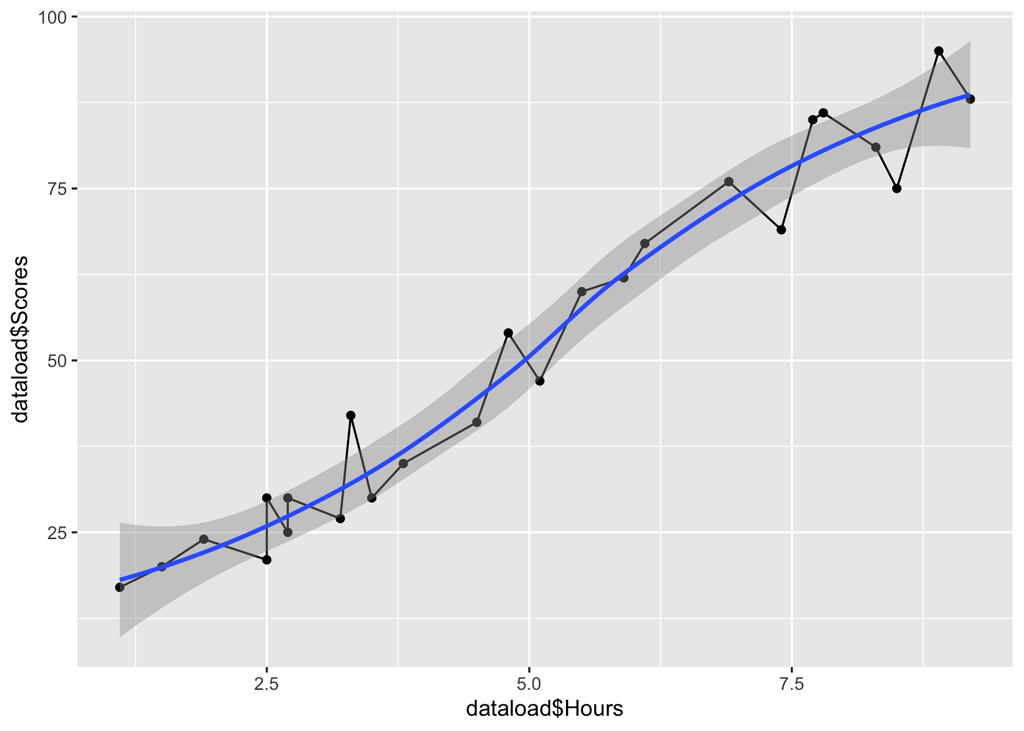

## In this graph, it clearly shows Students who are giving minimum time(hours) their marks is less and who is giving more time(hours) their marks are more. Let’s see more graph to clear more..